[figure not shown]

# Text Classification Assessment

### Goal: Given a set of text movie reviews that have been labeled negative or positive

For more information on this dataset visit http://ai.stanford.edu/~amaas/data/sentiment/

## Complete the tasks in bold below!

**Task: Perform imports and load the dataset into a pandas DataFrame** For this exercise you can load the dataset from `'../DATA/moviereviews.csv'`.

```python
# CODE HERE
```

```python
import numpy as np
import pandas as pd
```

```python
df = pd.read_csv('../DATA/moviereviews.csv')
```

```python
df.head()
```

|  | label | review |
| --- | --- | --- |
| 0 | neg | how do films like mouse hunt get into theatres... |
| 1 | neg | some talented actresses are blessed with a dem... |
| 2 | pos | this has been an extraordinary year for austra... |
| 3 | pos | according to hollywood movies made in last few... |
| 4 | neg | my first press screening of 1998 and already i... |

**TASK: Check to see if there are any missing values in the dataframe.**

```python
#CODE HERE
```

```
label      0
review    35
dtype: int64
```

**TASK: Remove any reviews that are NaN**

**TASK: Check to see if any reviews are blank strings and not just NaN. Note: This means a review text could just be: "" or " " or some other larger blank string. How would you check for this? Note: There are many ways! Once you've discovered the reviews that are blank strings, go ahead and remove them as well. [Click me for a big hint](https://pandas.pydata.org/pandas-docs/stable/reference/api/pandas.Series.str.isspace.html)**

```
27
```

|  | label | review |
| --- | --- | --- |
| 57 | neg |  |
| 71 | pos |  |
| 147 | pos |  |
| 151 | pos |  |
| 283 | pos |  |
| 307 | pos |  |
| 313 | neg |  |
| 323 | pos |  |
| 343 | pos |  |
| 351 | neg |  |
| 427 | pos |  |
| 501 | neg |  |
| 633 | pos |  |
| 675 | neg |  |
| 815 | neg |  |
| 851 | neg |  |
| 977 | neg |  |
| 1079 | neg |  |
| 1299 | pos |  |
| 1455 | neg |  |
| 1493 | pos |  |
| 1525 | neg |  |
| 1531 | neg |  |
| 1763 | neg |  |
| 1851 | neg |  |
| 1905 | pos |  |
| 1993 | pos |  |

```
<class 'pandas.core.frame.DataFrame'>
Int64Index: 1938 entries, 0 to 1999
Data columns (total 2 columns):
 #   Column  Non-Null Count  Dtype
---  ------  --------------  -----
 0   label   1938 non-null   object
 1   review  1938 non-null   object
dtypes: object(2)
memory usage: 45.4+ KB
```

**TASK: Confirm the value counts per label:**

```python
#CODE HERE
```

```
pos    969
neg    969
Name: label, dtype: int64
```

## EDA on Bag of Words

**Bonus Task: Can you figure out how to use a CountVectorizer model to get the top 20 words (that are not english stop words) per label type? Note, this is a bonus task as we did not show this in the lectures. But a quick cursory Google search should put you on the right path. [Click me for a big hint](https://stackoverflow.com/questions/16288497/find-the-most-common-term-in-scikit-learn-classifier)**

```python
#CODE HERE
```

[output not shown]

[output not shown]

### Training and Data

**TASK: Split the data into features and a label (X and y) and then preform a train/test split. You may use whatever settings you like. To compare your results to the solution notebook, use `test_size=0.20, random_state=101`**

```python
#CODE HERE
```

### Training a Mode

**TASK: Create a PipeLine that will both create a TF-IDF Vector out of the raw text data and fit a supervised learning model of your choice. Then fit that pipeline on the training data.**

```python
#CODE HERE
```

```
Pipeline(steps=[('tfidf', TfidfVectorizer()), ('svc', LinearSVC())])
```

**TASK: Create a classification report and plot a confusion matrix based on the results of your PipeLine.**

```python
#CODE HERE
```

```
              precision    recall  f1-score   support

         neg       0.81      0.86      0.83       191
         pos       0.85      0.81      0.83       197

    accuracy                           0.83       388
   macro avg       0.83      0.83      0.83       388
weighted avg       0.83      0.83      0.83       388
```

```
<sklearn.metrics._plot.confusion_matrix.ConfusionMatrixDisplay at 0x1f370d0b790>
```

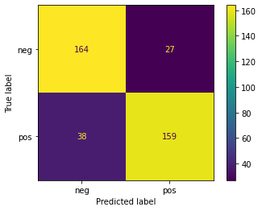